# Hands-on 3

Itxaso Alonso (itxaso.alonso01@estudiant.upf.edu)

Last update: `15/03/2026`

```r
if (!require("caret")){install.packages("caret"); require(caret)}
if (!require("randomForest")){install.packages("randomForest"); require(randomForest)}
if (!require("pROC")){install.packages("pROC"); require(pROC)}
if (!require("recipes")){install.packages("recipes"); require(recipes)}

### Load required packages
library(readxl)
library(caret)
library(recipes)
library(randomForest)
library(pROC)
library(dplyr)
library(ggplot2)

### Read the data
df_metadata <- readxl::read_xlsx("Data/Raw_Data/Table-S1.Additional-Demographical-and-Baseline-Characteristics-of-COVID-19-Patients-and-Control-Groups.xlsx", sheet = 2)

# Rename important columns
df_metadata <- df_metadata %>%
  rename(
    Patient_ID = `Patient ID a`,
    Group = `Group d`
  )

# Create variable severity (2-3)
df_metadata <- df_metadata %>%
  mutate(
    Patient_ID = trimws(as.character(Patient_ID)),
    Group = as.numeric(Group)
  ) %>%
  filter(Group %in% c(2,3)) %>%
  mutate(
    Severity = case_when(
      Group == 2 ~ "Non-severe",
      Group == 3 ~ "Severe"
    ),
    Severity = factor(Severity,
                      levels = c("Non-severe","Severe"))
  ) %>%
  select(Patient_ID, Severity)
```

```r
# In the paper they used 18 non-severe and 13 severe patients for training data

df_proteins <- readxl::read_xlsx("Data/Raw_Data/S3-Protein_and_Metabolite_Matrix.xlsx", sheet = 2, skip = 1)

# Clean IDs
df_proteins$...1 <- trimws(as.character(df_proteins$...1))

# Remove descriptive columns
df_proteins_clean <- df_proteins[, -c(1:2)]
rownames(df_proteins_clean) <- df_proteins$...1

# Transpose the matrix
training_data <-  as.data.frame(t(df_proteins_clean))
rownames(training_data) <- make.names(rownames(training_data), unique = TRUE)

# Confirm ID match
common_ids <- intersect(df_metadata$Patient_ID, rownames(training_data))
df_metadata <- df_metadata %>% filter(Patient_ID %in% common_ids)
training_data <- training_data[match(df_metadata$Patient_ID, rownames(training_data)), , drop = FALSE]

# Add Patient_ID as column
training_data <- tibble::rownames_to_column(training_data, var = "Patient_ID")

# Merge metadata with protein data
df_model <- inner_join(df_metadata, training_data, by = "Patient_ID")
rownames(df_model) <- df_model$Patient_ID
df_model <- df_model[,-1]

#Pre-processing from the study:
# compounds with over 80% missing ratios in a particular patient group were removed for the metabolomics dataset
#Metabolites and therapeutic compounds with over 80% missing ratios in a particular patient group were removed
#Missing values were imputed with the minimal value and zero in metabolomics and proteomics dataset respectively.

#Cols in our df
outcome_col <- 1
protein_cols <- 2:792
metab_cols   <- 793:1639

df_model[, protein_cols] <- lapply(df_model[, protein_cols], function(x) as.numeric(as.character(x)))

df_model <- df_model %>%
  select(-all_of(metab_cols))

#Proteins missing values, 0 imputation
df_model[, protein_cols] <- lapply(df_model[, protein_cols], function(x) {
  x[is.na(x)] <- 0
  x
})
```

# Exercise 1

**Build a Random Forest model to classify COVID-19 severity**

Using the training cohort provided in Supplementary Table 3, build a Random Forest classification model similar to the one in the publication to distinguish between non-Severe and Severe COVID-19 patients.

Report the following performance metrics from cross-validation:

- Confusion matrix
- Accuracy
- ROC curve and AUC

How well does the Random Forest model separate non-Severe from Severe patients based on proteomic profiles?

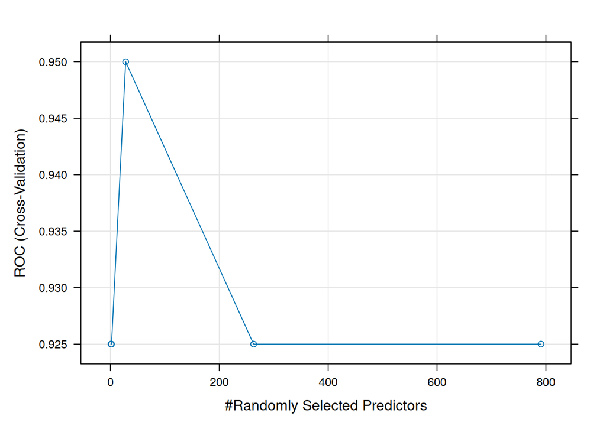

```r
# In the paper they used 18 non-severe and 13 severe patients for training data

# Before train the model (because caret convert the class names to column names when it calculates probabilities)
df_model$Severity <- as.character(df_model$Severity)

df_model$Severity[df_model$Severity == "Non-severe"] <- "Non.severe"

df_model$Severity <- factor(df_model$Severity,
                            levels = c("Non.severe", "Severe"))

# Model configuration
set.seed(123)
rf_recipe <- recipe(Severity ~ ., data = df_model)
ctrl <- trainControl(
  method = "cv",
  number = 10,
  classProbs = TRUE, # necessary for ROC
  summaryFunction = twoClassSummary, # calculate ROC, Sens, Spec
  savePredictions = "final"
)

p <- ncol(df_model) - 1 # Max numb of variables to try for RF, exclude classification
mtry_grid <- data.frame( mtry = c(1, 2, floor(sqrt(p)), floor(p/3), p) )

# Train of RF
rf_model <- train(
  rf_recipe,
  data = df_model,
  method = "rf",
  trControl = ctrl,
  tuneGrid = mtry_grid,
  ntree = 1000, #Number of trees built in the research
  importance = TRUE,
  metric = "ROC")


rf_model
plot(rf_model)
```

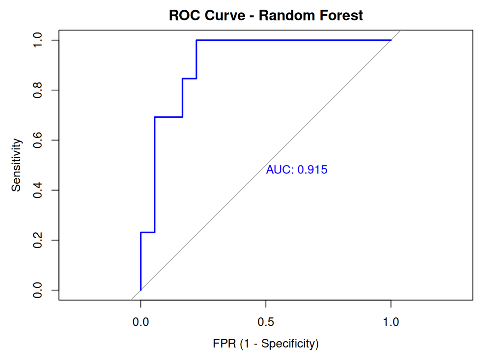

```r
# Save the file
png("Data/Processed_Data/rf_model_plot.png", width = 800, height = 600)
plot(rf_model)
invisible(dev.off())

# Extract best CV predictions
best_mtry <- rf_model$bestTune$mtry
predictions <- rf_model$pred
predictions <- predictions[predictions$mtry == best_mtry, ]


# Confusion Matrix
conf_mat <- confusionMatrix(
  predictions$pred,
  predictions$obs,
  positive = "Severe"
)
conf_mat$table


# Accuracy
accuracy <- conf_mat$overall["Accuracy"]
conf_mat$overall["Accuracy"]

#ROC and AUC

roc_obj <- roc(
  predictions$obs,
  predictions$Severe
)

auc_value <- auc(roc_obj)
auc_value

plot(
  roc_obj,
  print.auc = TRUE,
  col = "blue",
  main = "ROC Curve - Random Forest",
  legacy.axes = TRUE,
  xlab = "FPR (1 - Specificity)"
)
```

[output not shown]

```r
# Save the plot
png("Data/Processed_Data/roc_curve.png", width = 800, height = 600)
plot(
  roc_obj,
  print.auc = TRUE,
  col = "blue",
  main = "ROC Curve - Random Forest",
  legacy.axes = TRUE,
  xlab = "FPR (1 - Specificity)"
)
invisible(dev.off())
```

# Exercise 2

**Identify and interpret the most important features**

Using the trained Random Forest model from Exercise 1, identify the 25 most important protein features contributing to the classification. Disccus their biological relevance.

Compare your selected features to the proteins reported by the authors in Supplementary Table 5.

```r
df2_proteins <- readxl::read_xlsx("Data/Raw_Data/S5-Protein_and_Metabolite_Matrix.xlsx", sheet = 2, skip = 1)

# Variable importance
var_imp <- varImp(rf_model, scale = TRUE)

# Convert to data frame
importance_df <- var_imp$importance
importance_df$Protein <- rownames(importance_df)

# Create Overall column as a mean of both classes
importance_df$Overall <- rowMeans(importance_df[, 1:2])

# Sort by Overall
importance_df <- importance_df %>%
  arrange(desc(Overall))

# Top 25
top25_proteins <- importance_df[1:25, ] #Selecting the number of proteins used in the model

# Compare with Supplementary Table 5 to know which coincide
top25_proteins$Match <- ifelse(top25_proteins$Protein %in% df2_proteins[[1]], "Reported", "Not reported")

top25_proteins
```

```
##        Non.severe    Severe Protein   Overall        Match
## P0DJI9  100.00000 100.00000  P0DJI9 100.00000     Reported
## P02768   89.56933  89.56933  P02768  89.56933     Reported
## P0DJI8   88.16795  88.16795  P0DJI8  88.16795     Reported
## P02750   75.34669  75.34669  P02750  75.34669     Reported
## P00738   73.96462  73.96462  P00738  73.96462     Reported
## P02741   73.79323  73.79323  P02741  73.79323     Reported
## P13671   72.75916  72.75916  P13671  72.75916     Reported
## Q9UK55   71.02611  71.02611  Q9UK55  71.02611     Reported
## P02748   69.17982  69.17982  P02748  69.17982     Reported
## P01009   68.06807  68.06807  P01009  68.06807 Not reported
## P51884   67.11372  67.11372  P51884  67.11372     Reported
## P12259   65.16553  65.16553  P12259  65.16553     Reported
## P05156   64.05170  64.05170  P05156  64.05170 Not reported
## P05155   63.13450  63.13450  P05155  63.13450     Reported
## Q06033   61.62820  61.62820  Q06033  61.62820     Reported
## P15169   61.57644  61.57644  P15169  61.57644     Reported
## P05452   61.34387  61.34387  P05452  61.34387     Reported
## P33908   57.61144  57.61144  P33908  57.61144 Not reported
## P01011   57.35443  57.35443  P01011  57.35443     Reported
## P02763   56.64715  56.64715  P02763  56.64715 Not reported
## P35542   55.95085  55.95085  P35542  55.95085 Not reported
## P04004   53.26011  53.26011  P04004  53.26011 Not reported
## P01019   51.18706  51.18706  P01019  51.18706 Not reported
## Q96PD5   51.16448  51.16448  Q96PD5  51.16448     Reported
## Q14520   50.61041  50.61041  Q14520  50.61041     Reported
```

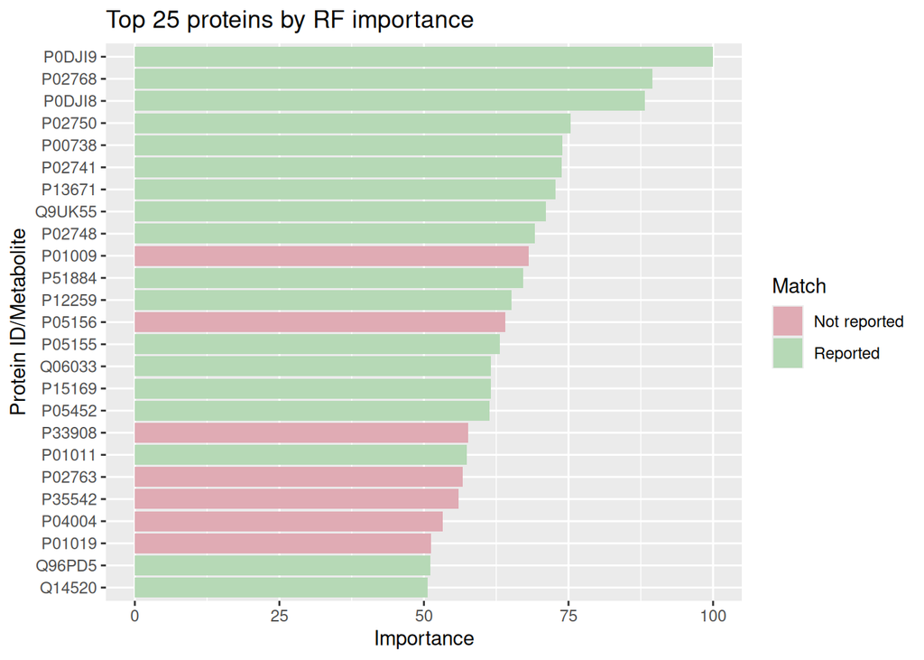

```r
top25 <- ggplot(top25_proteins, aes(x = reorder(Protein, Overall), y = Overall, fill = Match)) +
  geom_bar(stat = "identity") +
  coord_flip() +
  scale_fill_manual(values = c("Reported" = "#B6D9B6", "Not reported" = "#E0ABB4")) +
  labs(title = "Top 25 proteins by RF importance", x = "Protein ID/Metabolite", y = "Importance")

top25
```

```r
ggsave("Data/Processed_Data/top25.png", plot = top25, width = 15, height = 12, dpi = 300)
```

- We can see that most of the features selected for our model match the ones selected in the author’s model, except for: P01009, P05156, P33908, P02763, P35542, P04004, P01019. Nevertheless, the original research includes the metabolic parameters in their study, as a result some variation is expected.

# Exercise 3

**External prediction on an independent test cohort**

Using the final Random Forest model trained on the full training cohort, predict disease severity for patients in the independent test cohort provided in Supplementary Table 4.

Your task is to:

- Apply the trained model to the test cohort.
- Obtain predicted probabilities of Severe disease for each patient.
- Assign predicted class labels based on these probabilities.
- Compare predictions to the true clinical labels.

How does the model perform on the independent test cohort?

```r
# Read the test data
test_df <- readxl::read_xlsx("Data/Raw_Data/S4-Independent_Test_Cohort.xlsx", sheet = 2, skip = 1)

# Clean Patient_ID
test_df$...1 <- trimws(as.character(test_df$...1))

# Remove descriptive columns
test_clean <- test_df[, -c(1:2)]
rownames(test_clean) <- test_df$...1

# Transpose the matrix
test_data <- as.data.frame(t(test_clean))
rownames(test_data) <- make.names(rownames(test_data), unique = TRUE)

# Add Patient_ID
test_data <- tibble::rownames_to_column(test_data, var = "Patient_ID")


# Read the metadata
df_test_metadata <- readxl::read_xlsx("Data/Raw_Data/Table-S1.Additional-Demographical-and-Baseline-Characteristics-of-COVID-19-Patients-and-Control-Groups.xlsx", sheet = 2)

df_test_metadata <- df_test_metadata %>%
  rename(
    Patient_ID = `Patient ID a`,
    Group = `Group d`
  ) %>%
  mutate(
    Patient_ID = trimws(as.character(Patient_ID)),
    Group = as.numeric(Group)
  ) %>%
  filter(Group %in% c(2,3)) %>%
  mutate(
  Severity = case_when(
      Group == 2 ~ "Non.severe",
      Group == 3 ~ "Severe"
    ),
    Severity = factor(Severity,
                      levels = c("Non.severe","Severe"))
  )


# Join metadata with proteins
df_test <- inner_join(df_test_metadata, test_data, by = "Patient_ID")

rownames(df_test) <- df_test$Patient_ID
df_test <- df_test[,-1]

#Identify features common with training model
common_features <- intersect(colnames(df_model)[-1], colnames(df_test))

# Subset both datasets to common features
df_model_reduced <- df_model[, c("Severity", common_features)]
df_test_final <- df_test[, c("Severity", common_features)]

# Convert to numeric and impute NA
df_test_final[, -1] <- lapply(df_test_final[, -1], function(x) as.numeric(as.character(x)))
df_test_final[is.na(df_test_final)] <- 0


# Train the model with reduced features
set.seed(123)
rf_recipe <- recipe(Severity ~ ., data = df_model_reduced)
ctrl <- trainControl(
  method = "cv",
  number = 10,
  classProbs = TRUE,
  summaryFunction = twoClassSummary,
  savePredictions = "final"
)

p <- ncol(df_model_reduced) - 1
mtry_grid <- data.frame(mtry = c(1,2,floor(sqrt(p)), floor(p/3), p))

rf_model_reduced <- train(
  rf_recipe,
  data = df_model_reduced,
  method = "rf",
  trControl = ctrl,
  tuneGrid = mtry_grid,
  ntree = 1000,
  importance = TRUE,
  metric = "ROC"
)
```

- The Random Forest model was initially developed using the full training dataset. For external validation, only the features shared between the training and independent test cohorts were kept. As the test dataset did not contain all the feautres present in the training dataset, a final model was then re-trained on the training data using this reduced feature set to ensure compatibility with the test cohort.

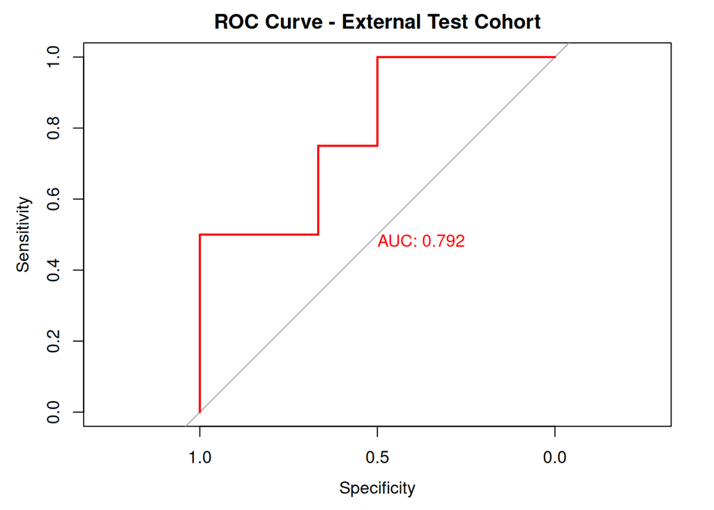

```r
# Predict on test cohort
test_probs <- predict(rf_model_reduced, df_test_final, type = "prob")
test_pred  <- predict(rf_model_reduced, df_test_final)

df_test_final$Predicted_Class <- test_pred
df_test_final$Prob_Severe <- test_probs$Severe

results_table <- data.frame(
  Sample = rownames(df_test_final),
  True_Severity = df_test_final$Severity,
  Predicted_Class = df_test_final$Predicted_Class,
  Prob_Severe = df_test_final$Prob_Severe
)

# Evaluate
conf_mat_test <- confusionMatrix(
  df_test_final$Predicted_Class,
  df_test_final$Severity,
  positive = "Severe"
)

accuracy_test <- conf_mat_test$overall["Accuracy"]

roc_test <- roc(df_test_final$Severity, df_test_final$Prob_Severe)
auc_test <- auc(roc_test)

# Plot ROC
plot(roc_test,
     print.auc = TRUE,
     col = "red",
     main = "ROC Curve - External Test Cohort")
```

```r
# Save the plot
png("Data/Processed_Data/ROC_test_EXT.png", width = 1200, height = 900)

plot(roc_test,
     print.auc = TRUE,
     col = "red",
     main = "ROC Curve - External Test Cohort")


# Print results
conf_mat_test
```

```
## Confusion Matrix and Statistics
##
##             Reference
## Prediction   Non.severe Severe
##   Non.severe          4      1
##   Severe              2      3
##
##                Accuracy : 0.7
##                  95% CI : (0.3475, 0.9333)
##     No Information Rate : 0.6
##     P-Value [Acc > NIR] : 0.3823
##
##                   Kappa : 0.4
##
##  Mcnemar's Test P-Value : 1.0000
##
##             Sensitivity : 0.7500
##             Specificity : 0.6667
##          Pos Pred Value : 0.6000
##          Neg Pred Value : 0.8000
##              Prevalence : 0.4000
##          Detection Rate : 0.3000
##    Detection Prevalence : 0.5000
##       Balanced Accuracy : 0.7083
##
##        'Positive' Class : Severe
##
```

```r
accuracy_test
```

```
## Accuracy
##      0.7
```

```r
auc_test
```

```
## Area under the curve: 0.7917
```

```r
cat("============ Predicted probabilties ============ ")
```

```
## ============ Predicted probabilties ============
```

```r
results_table
```

```
##    Sample True_Severity Predicted_Class Prob_Severe
## 1       1    Non.severe      Non.severe       0.157
## 2       2    Non.severe      Non.severe       0.495
## 3       3    Non.severe          Severe       0.625
## 4       4    Non.severe      Non.severe       0.143
## 5       5    Non.severe      Non.severe       0.162
## 6       6    Non.severe          Severe       0.706
## 7       7        Severe          Severe       0.793
## 8       8        Severe          Severe       0.731
## 9       9        Severe      Non.severe       0.483
## 10     10        Severe          Severe       0.618
```

# session info

R version 4.5.3 (2026-03-11) Platform: x86_64-pc-linux-gnu Running under: Ubuntu 24.04.4 LTS

Matrix products: default BLAS: /usr/lib/x86_64-linux-gnu/blas/libblas.so.3.12.0 LAPACK: /usr/lib/x86_64-linux-gnu/lapack/liblapack.so.3.12.0 LAPACK version 3.12.0

locale: [1] LC_CTYPE=en_US.UTF-8 LC_NUMERIC=C  
[3] LC_TIME=en_US.UTF-8 LC_COLLATE=en_US.UTF-8  
[5] LC_MONETARY=en_US.UTF-8 LC_MESSAGES=en_US.UTF-8  
[7] LC_PAPER=en_US.UTF-8 LC_NAME=C  
[9] LC_ADDRESS=C LC_TELEPHONE=C  
[11] LC_MEASUREMENT=en_US.UTF-8 LC_IDENTIFICATION=C

time zone: Europe/Madrid tzcode source: system (glibc)

attached base packages: [1] stats graphics grDevices utils datasets methods base

other attached packages: [1] readxl_1.4.5 recipes_1.3.1 dplyr_1.2.0  
[4] pROC_1.19.0.1 randomForest_4.7-1.2 caret_7.0-1  
[7] lattice_0.22-9 ggplot2_4.0.2

loaded via a namespace (and not attached): [1] gtable_0.3.6 xfun_0.57 bslib_0.10.0  
[4] vctrs_0.7.2 tools_4.5.3 generics_0.1.4  
[7] stats4_4.5.3 parallel_4.5.3 proxy_0.4-29  
[10] tibble_3.3.1 pkgconfig_2.0.3 ModelMetrics_1.2.2.2 [13] Matrix_1.7-4 data.table_1.18.2.1 RColorBrewer_1.1-3  
[16] S7_0.2.1 lifecycle_1.0.5 compiler_4.5.3  
[19] farver_2.1.2 stringr_1.6.0 codetools_0.2-20  
[22] htmltools_0.5.9 class_7.3-23 sass_0.4.10  
[25] yaml_2.3.12 prodlim_2026.03.11 pillar_1.11.1  
[28] jquerylib_0.1.4 MASS_7.3-65 cachem_1.1.0  
[31] gower_1.0.2 iterators_1.0.14 rpart_4.1.24  
[34] foreach_1.5.2 nlme_3.1-168 parallelly_1.46.1  
[37] lava_1.8.2 tidyselect_1.2.1 digest_0.6.39  
[40] stringi_1.8.7 future_1.70.0 reshape2_1.4.5  
[43] purrr_1.2.1 listenv_0.10.1 labeling_0.4.3  
[46] splines_4.5.3 fastmap_1.2.0 grid_4.5.3  
[49] cli_3.6.5 magrittr_2.0.4 survival_3.8-6  
[52] e1071_1.7-17 future.apply_1.20.2 withr_3.0.2  
[55] scales_1.4.0 lubridate_1.9.5 timechange_0.4.0  
[58] rmarkdown_2.30 globals_0.19.1 otel_0.2.0  
[61] nnet_7.3-20 timeDate_4052.112 cellranger_1.1.0  
[64] evaluate_1.0.5 knitr_1.51 hardhat_1.4.2  
[67] rlang_1.1.7 Rcpp_1.1.1 glue_1.8.0  
[70] ipred_0.9-15 rstudioapi_0.18.0 jsonlite_2.0.0  
[73] R6_2.6.1 plyr_1.8.9